# Capitulo 9 - Estadistica 2

Portada

```python
from IPython.display import display, HTML

htmlCod = """
<!DOCTYPE html>
<html lang="es">
<head>
<meta charset="UTF-8">
<meta name="viewport" content="width=device-width, initial-scale=1.0">
<style>
  body1 {
    font-family: 'Cambria', sans-serif;
    background-color: #FFF; /* Fondo blanco */
    color: #000; /* Texto negro */
    margin: 0;
    padding: 0;
  }
  .chapter-box {
    background-color: #009929;
    color: #FFF;
    padding: 20px 0; /* Ajusta este valor para centrar verticalmente como desees */
    width: 100%; /* Ancho al 100% para ocupar la parte superior de la pantalla */
    box-sizing: border-box; /* Asegura que el padding no añada más ancho */
    text-align: center; /* Centra el texto horizontalmente */
  }
  .chapter-box h1 {
    margin: 0;
    font-size: 6em; /* Tamaño CAPÍTULO 1 */
  }
  .content {
    padding: 20px;
    column-count: 2;
    column-gap: 40px;
  }
  .content h2 {
    color: #009929;
    font-size: 1.5em;
    margin-top: 0;
    font-weight: normal;
    text-transform: uppercase;
    text-align: left;
    border-bottom: 1px solid #009929; /* Línea debajo del texto */
    padding-bottom: 5px; /* Espacio entre texto y línea */
    display: inline-block; /* Permite que la línea ocupe el ancho del contenedor */
    width: 100%; /* Asegura que el subrayado se extienda a lo largo de la página */
  }
  .content ul {
    list-style-type: none; /* No queremos viñetas */
    padding: 0;
    margin-top: 0; /* Evitar espacios adicionales antes de la lista */
  }
  .content ul li {
    margin-bottom: 10px; /* Espaciado entre líneas */
    font-size: 1em;
  }
  .content ul li strong {
    font-weight: bold;
    display: block; /* Asegura que cada título de sección comience en una nueva línea */
    break-inside: avoid-column; /* Evita que los títulos de sección se dividan entre columnas */
    -webkit-column-break-inside: avoid; /* Para navegadores basados en WebKit como Safari */
    page-break-inside: avoid; /* Para la paginación al imprimir */
  }
</style>
</head>
</html>
"""

display(HTML(htmlCod))
```

from IPython.display import display, HTML htmlCod = """ """ display(HTML(htmlCod))

otros estilos

```python
from IPython.display import display, HTML

htmlCod = """
<style>
  body {
    font-family: 'Segoe UI', Tahoma, Geneva, Verdana, sans-serif;
    background: #fafafa;
    margin: 0;
    padding: 20px;
  }
  .encuesta {
    max-width: 700px;
    margin: auto;
    padding: 20px;
    background: #ffffff;
    box-shadow: 0 2px 5px rgba(0,0,0,0.1);
  }
  .encuesta h2 {
    text-align: center;
    color: #333333;
  }
  .campo {
    margin: 15px 0;
  }
  .campo label {
    margin: 0 10px 0 0;
    font-weight: bold;
  }
  .campo input[type="text"],
  .campo textarea {
    width: calc(100% - 22px);
    padding: 10px;
    margin-top: 5px;
    border: 1px solid #dddddd;
    border-radius: 4px;
  }
  .pregunta {
    margin: 15px 0;
  }
  .pregunta span {
    font-weight: bold;
  }
  .opciones label {
    margin-right: 5px;
  }
  .opciones input[type="checkbox"] {
    margin-right: 10px;
  }
  .comentario {
    margin: 15px 0;
  }
  .boton-envio {
    width: 100%;
    padding: 10px;
    background-color: #555555;
    color: white;
    border: none;
    border-radius: 4px;
    cursor: pointer;
  }
  .tabulado {
  margin-left: 20px; /* Esto añade espacio antes del elemento, como un tabulador. */
  .tab {
  margin-left: 20px; /* Esto añade espacio antes del elemento, como un tabulador. */
}
</style>
"""
display(HTML(htmlCod))
```

from IPython.display import display, HTML htmlCod = """ """ display(HTML(htmlCod))

```python
from IPython.display import display, HTML

htmlCod = """
<style>
  body {
    font-family: 'Segoe UI', Tahoma, Geneva, Verdana, sans-serif;
    background: #fafafa;
    margin: 0;
    padding: 20px;
  }
  .encuesta {
    max-width: 700px;
    margin: auto;
    padding: 20px;
    background: #ffffff;
    box-shadow: 0 2px 5px rgba(0,0,0,0.1);
  }
  .encuesta h2 {
    text-align: center;
    color: #333333;
  }
  .campo {
    margin: 15px 0;
  }
  .campo label {
    margin: 0 10px 0 0;
    font-weight: bold;
  }
  .campo input[type="text"],
  .campo textarea {
    width: calc(100% - 22px);
    padding: 10px;
    margin-top: 5px;
    border: 1px solid #dddddd;
    border-radius: 4px;
  }
  .pregunta {
    margin: 15px 0;
  }
  .pregunta span {
    font-weight: bold;
  }
  .opciones label {
    margin-right: 5px;
  }
  .opciones input[type="checkbox"] {
    margin-right: 10px;
  }
  .comentario {
    margin: 15px 0;
  }
  .boton-envio {
    width: 100%;
    padding: 10px;
    background-color: #555555;
    color: white;
    border: none;
    border-radius: 4px;
    cursor: pointer;
  }
  .tabulado {
  margin-left: 20px; /* Esto añade espacio antes del elemento, como un tabulador. */
  .tab {
  margin-left: 20px; /* Esto añade espacio antes del elemento, como un tabulador. */
}
</style>
"""
display(HTML(htmlCod))
```

from IPython.display import display, HTML htmlCod = """ """ display(HTML(htmlCod))

# CAPITULO 9

# Pruebas de hipotesis

## CONTENIDO

- **9.1 FORMULACION DE LAS HIPOTESIS NULA Y ALTERNATIVA**
- Lahipotesis alternativa como hipotesis de investigacion
- la hipotesis nula como un supuesto para ser rebatido
- Formas para la hipotesis nula y alternativa
- **9.2 ERRORES TIPO I Y TIPO II**
- **9.3 MEDIA POBLACIONAL $\sigma$ CONOCIDA**
- Prueba de una cola
- Prueba de dos colas
- Resumen y consejo practico
- Relacion entre estimacion por intervalo y prueba de hipotesis
- **9.4 MEDIA POBLACIONAL $\sigma$ DESCONOCIDA**
- Prueba de una cola
- Prueba de dos colas
- Resumen y consejo practico
- **9.5 PROPORCION POBLACIONAL**
- Resumen
- **9.6 PRUEBA DE HIPOTESIS Y TOMA DE DECISIONES**
- **9.7 CALCULO DE LA PROBABILIDAD DE LOS ERRORES TIPO II**
- **9.8 DETERMINACION DEL TAMAÑO DE LA MUESTRA EN UNA PRUEBA DE HIPOTESIS PARA LA MEDIA POBLACIONAL**

En primer lugar es importante comprender que una hipótesis es una afirmacion que puede ser sometida a prueba para determinar si es verdadera o falsa. Esta nos proporciona una estructura para investigar y analizar si la evidencia respalda o contradice la afirmación. A continuación, se presenta un ejemplo para ilustrar este concepto:

# Ejemplo

Imagina que piensas que la mayoría de los estudiantes de la carrera de informática de la UMSA prefiere utilizar laptops en lugar de computadoras de escritorio. Para comprobar si esto es cierto, planteas dos posibilidades:

### Afirmación:

La mayor parte de los estudiantes de la carrera de informática de la UMSA tienen preferencia por laptops en lugar de computadoras de escritorio.

### Negación:

No todos los estudiantes de la carrera de informática de la UMSA comparte preferencia por laptops en lugar de computadoras de escritorio.

Luego, observas las elecciones de dispositivos de los estudiantes y revisas los datos para ver cuál de estas posibilidades parece más acertada. Si los datos respaldan la idea de que la mayoría prefiere laptops, entonces tu idea original queda reforzada. Sin embargo, si los datos indican que no hay una preferencia clara o que no todos prefieren laptops, podrías reconsiderar tu idea inicial.

Basicamente se trata de probar y ver si lo que piensas está respaldado por la evidencia o si necesitas cambiar tu perspectiva.

En estadistica platearemos dos tipos de hipotesis la Hipotesis Nula $𝐻_𝑜$y la Hipotesis Alternativa $𝐻_𝑎$.La hipótesis nula $𝐻_0$ representa una suposición inicial sobre un parámetro poblacional, como la media o la proporción, es co mo una afirmación que estamos dispuestos a poner a prueba. Por otro lado la Hipotesis Alternativa $𝐻𝑎$ es una declaración que va en contra de la hipótesis nula es la idea que estamos tratando de respaldar con nuestra investigación. Generalmente la hipótesis nula sostiene de que no hay un efecto o diferencia importante, mientras que la hipótesis alternativa plantea que sí existe algo significativo que merece ser descubierto o investigado

## 9.1 Formulación de la hipótesis nula y alternativa

En el proceso para formular las hipótesis nula y alternativa, es importante estructurarla correctamente para obtener conclusiones útiles en las pruebas de hipótesis. Depende en gran medida del contexto de la situación para formular la hipotesis,como tambien la recolección de una muestra y el uso de resultados muestrales son importantes todas las aplicaciones de prueba de hipótesis para respaldar conclusiones. Al realizar la formulación de las hipótesis, es importante considerar preguntas clave, como el propósito de recolectar la muestra y las conclusiones esperadas. El proceso de identificar la hipótesis nula y alternativa puede variar dependiendo de las situaciones, es más sencillo identificar la hipótesis alternativa primero y luego desarrollar la nula, mientras que en otras situaciones ocurre lo contrario.

# La hipótesis alternativa como hipótesis de investigación

En muchas ocasiones al hacer pruebas de hipótesis, comenzamos enfocándonos en respaldar nuestra idea original. Esto se logra mediante la formulación de la hipótesis alternativa, que básicamente es nuestra idea inicial. Al rechazar la hipótesis nula, estamos dando paso para aceptar nuestra hipótesis de investigación, la idea que queremos respaldar,es como decir "pensamos que hay algo interesante aquí y queremos demostrarlo". Este proceso actúa como una guía en nuestra investigación, permitiéndonos evaluar si los resultados que observamos respaldan o contradicen nuestra hipotesis iniciales.

# Ejemplo

En este caso, planteamos la idea de que, en general, los estudiantes no superan una nota de 75, pero nos interesa investigar si aquellos que estudian al menos 8 horas a la semana obtienen calificaciones superiores.

Estamos formulando una pregunta de investigación específica sobre la relación entre el tiempo de estudio y el rendimiento académico, considerando abiertamente la posibilidad de que más tiempo de estudio esté asociado con notas superiores a 75.

$ H_0: \mu \leq 75$

$ H_a: \mu > 75$

Si los resultados conducen a rechazar $H_0$, podemos afirmar que $ \mu > 75$ es verdadera. Al hacerlo, estamos aceptando la evidencia significativa de que los estudiantes de estadística que dedican al menos 8 horas a la semana de estudio tienen un rendimiento académico mejorado, con una media de calificaciones mayor a 75.

Si rechazamos $H_0$, no podemos concluir que la Hipótesis Nula $H_0$ —la cantidad promedio de tiempo de estudio no tiene un impacto significativo en las notas promedio de los estudiantes de estadística, y la media de las notas es igual o menor a 75 sea válida.

Este ejemplo puede aplicarse en diversas situaciones, como el rendimiento en exámenes, el tiempo de estudio y la mejora en las calificaciones.

$ H_0: \mu \leq 75$

$ H_a: \mu > 75$

Si los resultados conducen a rechazar $H_0$, podemos afirmar que $ \mu > 75$ es verdadera. Al hacerlo, estamos aceptando la evidencia significativa de que los estudiantes de estadística que dedican al menos 8 horas a la semana de estudio tienen un rendimiento académico mejorado, con una media de calificaciones mayor a 75.

Si rechazamos $H_0$, no podemos concluir que la Hipótesis Nula $H_0$ —la cantidad promedio de tiempo de estudio no tiene un impacto significativo en las notas promedio de los estudiantes de estadística, y la media de las notas es igual o menor a 75 sea válida.

Este ejemplo puede aplicarse en diversas situaciones, como el rendimiento en exámenes, el tiempo de estudio y la mejora en las calificaciones.

# La hipótesis nula como un supesto para ser rebatido

En el análisis de pruebas de hipótesis, se destaca la hipótesis nula es como una idea inicial que tratamos de cuestionar. No siempre estamos investigando algo nuevo, a veces partimos de la creencia de que una afirmación sobre un grupo de cosas es verdadera ,luego usamos la prueba de hipótesis para ver si hay evidencia estadística que indica lo contrario. En otras palabras es como decir: "Aquí hay algo que creemos, pero queremos ver si los datos nos dicen que estamos equivocados".

# Ejemplo

$H_0: \mu \geq 67.6$

$H_a: \mu < 67,6$

Si se rechaza la hipótesis nula, se infiere que la afirmación del fabricante es incorrecta, respaldando así la hipótesis alternativa. En este caso, la agencia gubernamental puede tomar medidas para garantizar el cumplimiento de los estándares de etiquetado. Sin embargo, si no se puede rechazar la hipótesis nula, no hay evidencia suficiente para cuestionar la afirmación del fabricante, y no se toma ninguna acción basada en la prueba de hipótesis. Este proceso destaca la importancia de la hipótesis nula como punto de partida para la evaluación de afirmaciones y la toma de decisiones basada en evidencia estadística.

# Formas para la hipotesis nula y alternativa

En las pruebas de hipótesis para la media poblacional, hay tres formas de plantear las hipótesis nula $H_0$ y alternativa $H_a$. Estas se dividen en pruebas de una cola y pruebas de dos colas. Aquí están las tres formas:

| $H_0: \mu \leq \mu_0$ | $H_0: \mu \geq \mu_0$ | $H_0: \mu = \mu_0$ |
| --- | --- | --- |
| $H_a: \mu > \mu_0$ | $H_a: \mu < \mu_0$ | $H_a: \mu \neq \mu_0$ |

Estas formas reflejan la dirección en la que se está interesado en encontrar evidencia significativa. Si se espera que la media poblacional sea mayor que $\mu_0$, se elige la primera forma; si se espera que sea menor, se elige la segunda forma. La tercera forma se selecciona cuando el interés es determinar si hay alguna diferencia significativa, ya sea mayor o menor.

Es importante destacar que la igualdad siempre aparece en la hipótesis nula $H_0$, ya sea con el símbolo de igualdad $=$.

La elección entre estas formas depende de la pregunta que se busca responder y de la dirección de la evidencia que se espera encontrar. Si se busca respaldar la idea de que la media es mayor, menor o simplemente diferente de $\mu_0$, entonces se elige la forma correspondiente para $H_a$.

Este enfoque permite estructurar adecuadamente las pruebas de hipótesis para la media poblacional y proporciona un marco claro para interpretar los resultados. La comprensión de estas formas es esencial para evitar errores tipo I y tipo II y garantizar que las pruebas sean efectivas en la evaluación de las afirmaciones sobre la media poblacional.

# Ejercicios

## Métodos

### Ejercicio 1

El gerente del Danvers-Hilton Resort Hotel afirma que la cantidad media que gastan los huéspedes en un fin de semana es de $4,148 bs$ o menos. Un miembro del equipo de contadores observó que en los últimos meses habían aumentado tales cantidades. El contador emplea una muestra de las cuentas de fin de semana de los huéspedes para probar la afirmación del gerente.

a) **¿Qué forma de hipótesis deberá usar para probar la afirmación del gerente? Explique**

$H_0: \mu \geq 4,148 $ - $H_0: \mu \leq 4,148 $-$ H_0: \mu = 4,148$

$H_a: \mu < 4,148 $ - $H_a: \mu >4,148 $ -$H_a: \mu \neq 4,148$

b) **¿Cuál es la conclusión apropiada cuando no se puede rechazar la hipótesis nula $H_0$**

c) **¿Qué conclusión es adecuada cuando se puede rechazar la hipótesis nula $H_0$?**

# Solución

a)

$H_0: \mu \leq 4,148$  
$H_a: \mu > 4,148$

Esto indica que la afirmación nula $H_0$ es que la cantidad media que gastan los huéspedes en un fin de semana es igual o menor que 4,148 bs. La hipótesis alternativa $H_a$ sería que la cantidad media es mayor de 4,148 bs.

b) Cuando no se puede rechazar la hipótesis nula $H_0$la conclusión apropiada es que no hay evidencia suficiente para afirmar que la cantidad media que gastan los huéspedes en un fin de semana es mayor que 4,148𝑏𝑠. En otras palabras, se acepta la afirmación del gerente..

c) Cuando se puede rechazar la hipótesis nula $H_0$la conclusión adecuada es que hay evidencia suficiente para afirmar que la cantidad media que gastan los huéspedes en un fin de semana es mayor que 4,148𝑏𝑠.

### Ejercicio 2

El gerente de un negocio de venta de automóviles piensa en un nuevo plan de bono diseñado para incrementar el volumen de ventas. En el momento actual, el volumen medio de ventas es 14 automóviles por mes. El gerente desea realizar un estudio para ver si el plan de bono incrementa el volumen de ventas. Para recolectar los datos, se le permitirá a una muestra de vendedores vender bajo el nuevo plan de bono durante un mes.

a) **Desarrolle las hipótesis nula y alternativa más adecuadas para esta situación.**

b) **Comente la conclusión en caso de que no pueda rechazarse $H_0$.**

c) **Comente la conclusión en caso de que pueda rechazarse $H_0$**

# Solución

a)

$H_0: \mu \leq 14$  
$H_a: \mu > 14$

b) No hay evidencia de que el nuevo plan incremente las ventas

c) La hipótesis de investigación $μ 14$ es apoyada, el nuevo plan incrementa las ventas

### Ejercicio 3

Una operación de la línea de producción está diseñada para llenar cajas con un peso medio de 32 onzas de detergente para lavar. Con periodicidad se selecciona una muestra de los empaques y se pesan para determinar si se están llenando de manera insuficiente o en demasía. Si los datos muestrales llevan a la conclusión de que hay llenado insuficiente o excesivo, la producción se suspende y se ajusta al llenado correcto.

a) **Formule las hipótesis nula y alternativa que ayudarán a determinar si se debe detener la producción y ajustar el peso.**

b) **Comente sobre la conclusión y la decisión en caso de que $H_0$ no se pueda rechazar.**

c) **Comente acerca de la conclusión y la decisión en caso de que $H_0$ se pueda rechazar.$**

# Solución

### a) Formulación de hipótesis:

El proceso de formulación de hipótesis implica establecer dos declaraciones ,la hipótesis nula $H_0$ y la hipótesis alternativa $H_a$ estamos interesados en determinar si el peso de las cajas de detergente es adecuado.

**Hipótesis nula ($H_0$):** El peso medio de las cajas de detergente es igual a 32 onzas.

**Hipótesis alternativa $H_a$** El peso medio de las cajas de detergente no es igual a 32 onzas (puede ser menor o mayor).

$H_0: \mu = 32$  
$H_a: \mu \neq 32 $

En palabras, estas hipótesis establecen que la producción se considera adecuada si el peso medio de las cajas de detergente es igual a 32 onzas (nula), y se considera inadecuada si el peso medio es diferente de 32 onzas (alternativa).

### b) Conclusión y decisión si $H_0$ no se puede rechazar:

Si no se puede rechazar $H_0$ es decir, si no hay suficiente evidencia para afirmar que el peso medio difiere de 32 onzases, es decir la producción actual cumple con los estándares y no es necesario realizar ajustes. En este caso, no se detendría la producción ni se realizarían ajustes al peso de las cajas.

### c) Conclusión y decisión si $H_0$ se puede rechazar:

Si se puede rechazar $H_0$ es decir, si hay suficiente evidencia para afirmar que el peso medio difiere de 32 onzas, la producción actual no cumple con los estándares y es necesario realizar ajustes. En este caso, se detendría la producción y se llevarían a cabo ajustes para garantizar que el peso de las cajas de detergente sea el adecuado.

### Ejercicio 4

Antes de implantar un método de fabricación propuesto, y debido a los costos y al tiempo de adaptación de la producción, un director de manufactura debe convencer a la dirección de que ese método nuevo reducirá los costos. El costo medio del actual método de producción es $220 por hora. Un estudio de investigación medirá el costo del método nuevo durante un periodo muestral de producción.

a) **Formule las hipótesis nula y alternativa más adecuadas para este estudio.**

b) **Comente acerca de la conclusión cuando $H_0$ no pueda rechazarse.**

c) **Comente acerca de la conclusión cuando $H_0$ pueda rechazarse.$**

# Solución

a)

Hipótesis nula $H_0$: El costo medio del nuevo método de producción es igual al costo medio del método actual.

Hipótesis alternativa $H_a$ El costo medio del nuevo método de producción es diferente al costo medio del método actual.

$H_0: \mu = 220$  
$H_a: \mu \neq 220$

b) Si no se puede rechazar $H_0$, se concluye que no hay suficiente evidencia para afirmar que el costo medio del nuevo método es diferente al del método actual. En este caso, no se tendría base estadística para convencer a la dirección de que el nuevo método reducirá los costos..

c) Si se puede rechazar $H_0$, se concluye que hay evidencia estadística para afirmar que el costo medio del nuevo método es diferente al del método actual. En este caso, el director de fabricación podría utilizar estos resultados como base para convencer a la dirección de que el nuevo método reducirá los costos.

## 9.2 Errores tipo I y tipo II

Las hipótesis nula y alternativa son afirmaciones opuestas acerca de la población. Una de las dos, ya sea la hipótesis nula $H_0$ o la alternativa $H_a$, es verdadera, pero no ambas. Lo ideal es que la prueba de hipótesis lleve a la aceptación de $H_0$ cuando sea verdadera y a su rechazo en $H_a$ sea verdadera,sin enbargo debe considerarse que existe la posibilidad de un error.

## Condicion poblacional

**Tabla 1**

Errores y conclusiones correctas en las pruebas de hipotesis

[output not shown]

En la figura, se representa gráficamente qué sucede cuando se acepta o se rechaza $H_0$. Si $H_0$es aceptada y es verdadera, la conclusión es correcta. Pero si $H_a$ es verdadera, se comete un Error Tipo II al aceptar incorrectamente $H_0$. Si $H_0$ es rechazada y es verdadera, se comete un Error Tipo I, pero si Ha es verdadera, es correcto rechazar $H_0$.

##### NIVEL DE SIGNIFICANCIA

Consiste en comter un Error de tipo I cuando $H_0$ es verdadera como igualdad

La probabilidad de cometer el Error Tipo I se controla con el nivel de significancia (α), que es la probabilidad de rechazar $H_0$ cuando es verdadera. Elegir un α más pequeño reduce la probabilidad de este error, pero aumenta la probabilidad de cometer el Error Tipo II.

## Video: Error de tipo I y tipo II

```python
# importar la clase que permite ver videos
from IPython.display import YouTubeVideo
# crear una instancia del objeto YouTubeVideo
youtube_video=YouTubeVideo('dtXMIQp2n5U')
#mostrar el video de youtube
display(youtube_video)
```

# importar la clase que permite ver videos from IPython.display import YouTubeVideo # crear una instancia del objeto YouTubeVideo youtube_video=YouTubeVideo('dtXMIQp2n5U') #mostrar el video de youtube display(youtube_video)

[video not shown]

# Ejercicios

### Ejercicio 5

Nielsen informó que los hombres jóvenes estadounidenses ven diariamente 56.2 minutos de televisión en las horas de mayor audiencia (The Wall Street Journal Europe, 18 de noviembre de 2003). Un investigador cree que en Alemania los jóvenes ven más tiempo la televisión en las horas de mayor audiencia. Este investigador toma una muestra de hombres jóvenes alemanes y registra el tiempo que ven televisión en un día. Los resultados muestrales se usan para probar las siguientes hipótesis nula y alternativa.

$H_0: \mu \leq 56.2$  
$H_a: \mu > 56.2$

a) **¿Cuál es el error tipo I en esta situación? ¿Qué consecuencia tiene cometerlo?**

b) **¿Cuál es el error tipo II en esta situación? ¿Qué consecuencia tiene cometerlo?**

# Solución

a)

Definición:Rechazar incorrectamente la hipótesis nula $H_0$cuando es verdadera.

Consecuencia: Concluir que los jóvenes alemanes ven más tiempo la televisión en las horas de mayor audiencia cuando, de hecho, no hay evidencia suficiente para respaldar esta afirmación. Puede llevar a tomar decisiones o implementar cambios basados en información incorrecta.

b) Definición: No rechazar la hipótesis nula $H_0$cuando es falsa.

Consecuencia: No reconocer que los jóvenes alemanes ven más tiempo la televisión en las horas de mayor audiencia cuando, de hecho, hay evidencia para respaldar esta afirmación. Puede llevar a perder la oportunidad de tomar decisiones informadas o implementar cambios necesarios.

### Ejercicio 6

En la etiqueta de una botella de jugo de naranja de 3 cuartos de galón se afirma que el jugo contiene en promedio 1 gramo o menos de grasa. Responda las preguntas siguientes relacionadas con una prueba de hipótesis para probar lo que se asegura en la etiqueta.

a) **Desarrolle las hipótesis nula y alternativa adecuadas.**

b) **¿Cuál es el error tipo I en esta situación? ¿Qué consecuencias tiene cometerlo?**

c) **¿Cuál es el error tipo II en esta situación? ¿Qué consecuencias tiene cometerlo?**

# Solución

a)

$H_0: \mu \leq 1$  
$H_a: \mu > 1$

$H_0$: La afirmación en la etiqueta es verdadera; el jugo de naranja tiene 1 gramo o menos de grasa en promedio.

$H_a$: La afirmación en la etiqueta es falsa; el jugo de naranja tiene más de 1 gramo de grasa en promedio.

b) Error Tipo I: Definición: Rechazar incorrectamente la hipótesis nula$H_0$ cuando es verdadera.

Consecuencia: Concluir que el jugo de naranja tiene más de 1 gramo de grasa en promedio cuando, de hecho, la afirmación en la etiqueta es correcta. Esto podría llevar a decisiones incorrectas sobre la producción, marketing u otras áreas basadas en información incorrecta.

c) Error Tipo II: Definición: No rechazar la hipótesis nula $H_0$cuando es falsa.

Consecuencia: No reconocer que el jugo de naranja tiene más de 1 gramo de grasa en promedio cuando, de hecho, la afirmación en la etiqueta es falsa. Esto podría llevar a que el producto se comercialice como bajo en grasa cuando no lo es, lo que podría afectar la confianza del consumidor y la reputación del producto.

### Ejercicio 7

El personal de ventas de Carpetland tiene un promedio de $8 000 semanales en ventas. Steve Contois, vicepresidente de la empresa, propone un plan de compensación con nuevos incentivos. Steve espera que los resultados de un periodo de prueba permitirán concluir que el plan de compensación aumenta el promedio de ventas de los vendedores.

a) **Establezca las hipótesis nula y alternativa adecuadas.**

b) **¿Cuál es el error tipo I en esta situación? ¿Qué consecuencias tiene cometerlo?.**

c) **¿Cuál es el error tipo II en esta situación? ¿Qué consecuencias tiene cometerlo?**

# Solución

a)

$H_0: \mu \leq 8,000$  
$H_a: \mu > 8,000$

$H_0$: El plan no aumenta el promedio de ventas.

$H_a$: El plan aumenta el promedio de ventas.

b) Rechazar incorrectamente $H_0$cuando es cierta. Consecuencia: Implementar un plan que no mejora las ventas, con costos innecesarios.

c)No rechazar$H_0$ cuando $H_a$ es cierta. Consecuencia: Perder la oportunidad de implementar un plan beneficioso que aumenta las ventas.

## 9.3 Medida Poblacional: σ conocida

En esta sección se muestra cómo realizar una prueba de hipótesis para la media poblacional en el caso en que σ es conocida.

Los métodos que se presentan dan resultados exactos si la población de la que se selecciona la muestra tiene distribución normal. En los casos en los que no sea razonable suponer que la población tiene esta distribución, se pueden aplicar estos métodos siempre y cuando el tamaño de la muestra sea suficientemente grande.

# Prueba de una cola

La **prueba de una cola** para la media poblacional toma una de las dos formas siguientes.

| **Prueba de cola inferior (o izquierda)** | **Prueba de cola superior (o derecha)** |
| --- | --- |
| $$H_0: μ ≥ μ_0$$ | $$H_0: μ ≤ μ_0$$ |
| $$H_a: μ < μ_0$$ | $$H_a: μ > μ_0$$ |

A continuación se presenta un ejemplo de una prueba para la cola inferior:  
El Instituto Boliviano de Regulación Comercial (IBRC) realiza estudios para verificar afirmaciones de fabricantes sobre productos, como el peso de café en latas de "Café Sierra".

- La hipótesis nula ($H_0$) establece que la media poblacional del peso de llenado es al menos 3 libras por lata: $H_0: μ ≥ 3$
- La hipótesis alternativa ($H_a$) sugiere que la media es menor de 3 libras: $H_0: μ < 3$

Se utiliza un nivel de significancia ($α = 0.01$). En el caso de "Café Sierra", si los datos no rechazan $H_0$, no se toman medidas; de lo contrario, se concluye que $H_a$ es verdadera, lo que justificaría un cargo por violación en la etiqueta. El director de pruebas de la IBRC está dispuesto a asumir un riesgo del 1% de cometer un error tipo I.

Se selecciona una muestra de 36 latas y se calcula la media muestral $x$ como una estimación de la media poblacional $μ$. Si $x$ es menor de 3 libras, se cuestiona la hipótesis nula. El factor clave es el valor de $α$, la probabilidad de cometer un error tipo I. Con los pasos iniciales completados, el siguiente paso es recopilar datos muestrales y calcular el estadístico de prueba para tomar una decisión basada en la evidencia estadística.

### Estadístico de prueba

ESTADÍSTICO DE PRUEBA EN LAS PRUEBAS DE HIPÓTESIS PARA LA MEDIA POBLACIONAL: σ CONOCIDA

$$z = \frac{{\bar{x} - \mu_0}}{{\frac{\sigma}{\sqrt{n}}}}$$

En el estudio de "Café Sierra", se realizan pruebas de hipótesis para la media poblacional ($μ$) en el caso de que la desviación estándar poblacional ($σ$) sea conocida. Los resultados previos de la IBRC indican que $σ$ tiene un valor de 0.18 y que la distribución de los pesos de llenado en la población sigue una distribución normal.

Con un tamaño de muestra $n = 36$ y asumiendo la hipótesis nula $H_0$ como verdadera $μ = μ_0 = 3$, se puede ilustrar la distribución de muestreo de la media muestral $\bar{x}$ en una distribución normal. El error estándar de $\bar{x}(σ_\bar{x})$ se calcula como $\frac{\sigma}{\sqrt{n}} = \frac{0.18}{\sqrt{36}} = 0.03 $

La variable aleatoria normal estándar:

#### $z =\frac{\bar{x} - \mu_0}{\sigma_{\bar{x}}} = \frac{\bar{x} - 3}{0.03}$

La probabilidad asociada a un valor específico de $z$ en la cola inferior se determina utilizando la tabla de probabilidad normal estándar.

Por ejemplo, si $z=-3.00$, el área en la cola inferior es $0.0013$, lo que significa que la probabilidad de obtener un valor de $\bar{x}$ que sea tres o más errores estándar menor que la media hipotética ($\mu_0=3$) es $0.0013$. En una prueba de hipótesis, un resultado tan extremo sugiere que la hipótesis nula es poco probable, lo que podría llevar al rechazo de la hipótesis nula en favor de la hipótesis alternativa. El estadístico de prueba utilizado es $z$, y se compara con un umbral crítico basado en el nivel de significancia predefinido ($α$).

FIGURA 9.1

Distribución de muestreo de x en el estudio de "Café Sierra" cuando la hipótesis nula es verdadera como igualdad (μ = 3)

```python
import numpy as np
import matplotlib.pyplot as plt
from scipy.stats import norm

# Parámetros de la distribución muestral
media_poblacional = 3
error_estandar = 0.03
# Generar datos de la distribución muestral
x = np.linspace(media_poblacional - 4 * error_estandar, media_poblacional + 4 * error_estandar, 1000)
y = norm.pdf(x, media_poblacional, error_estandar)

# Crear la gráfica
fig, ax = plt.subplots()
ax.plot(x, y, color='#009929')
# Establecer el color de fondo
ax.set_facecolor('#d4f8b7')
# Pintar el fondo externo del gráfico
fig.patch.set_facecolor('#D4F8B7')
ax.set_xlabel(f'μ = {media_poblacional}', fontsize=12)
ax.set_ylabel(r'Distribución de muestreo de $\bar{x}$', fontsize=12)

# Agregar información sobre el error estándar
info_error_estandar = r'$σ_\bar{x}$ = $\frac{\sigma}{\sqrt{n}} = \frac{0.18}{\sqrt{36}} = 0.03 $'
ax.text(0.6, 0.85, info_error_estandar, transform=ax.transAxes, fontsize=12, color='#000')

ax.grid(False)
plt.show()
```

import numpy as np import matplotlib.pyplot as plt from scipy.stats import norm # Parámetros de la distribución muestral media_poblacional = 3 error_estandar = 0.03 # Generar datos de la distribución muestral x = np.linspace(media_poblacional - 4 * error_estandar, media_poblacional + 4 * error_estandar, 1000) y = norm.pdf(x, media_poblacional, error_estandar) # Crear la gráfica fig, ax = plt.subplots() ax.plot(x, y, color='#009929') # Establecer el color de fondo ax.set_facecolor('#d4f8b7') # Pintar el fondo externo del gráfico fig.patch.set_facecolor('#D4F8B7') ax.set_xlabel(f'μ = {media_poblacional}', fontsize=12) ax.set_ylabel(r'Distribución de muestreo de $\bar{x}$', fontsize=12) # Agregar información sobre el error estándar info_error_estandar = r'$σ_\bar{x}$ = $\frac{\sigma}{\sqrt{n}} = \frac{0.18}{\sqrt{36}} = 0.03 $' ax.text(0.6, 0.85, info_error_estandar, transform=ax.transAxes, fontsize=12, color='#000') ax.grid(False) plt.show()

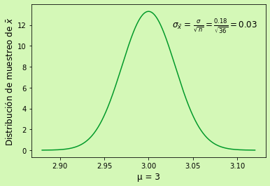

La cuestión clave en una prueba de cola inferior es: **¿qué tan pequeño debe ser el estadístico de prueba z para que se decida rechazar la hipótesis nula?** Para responder esta pregunta se usandos métodos: el método del **valor-p** y el **método del valor crítico**.

### Método del valor-p

En este enfoque se usa el valor del estadístico de prueba $z$ paracalcular una probabilidad llamada **valor-p**.

> **VALOR-p:** Es una probabilidad que aporta una medida de la evidenciasuministrada por la muestra contra la hipótesis nula. Valores-p pequeños indican una evidencia mayor contra $H_0$.

El valor - p se utiliza para determinar si la hipótesis nula debe ser rechazada.

El cálculo del valor-p depende del tipo de prueba (cola inferior, cola superior o dos colas). Para una prueba de cola inferior con $σ$ conocida, se determina el área bajo la curva normal estándar para valores de $z ≤$ al valor del estadístico de prueba.

Ahora calculamos el valor-p para la prueba de cola inferior del estudio de **"Café Sierra"**.Suponga que en la muestra de las 36 latas de café, la media muestral obtenida es $\bar{x} = 2.92$ libras. ¿Es $\bar{x} = 2.92$ lo suficientemente pequeña para que se rechace $H_0$? Como es una prueba de cola inferior, el valor-p es el área bajo la curva normal estándar para valores de $z$ que el valor del estadístico de prueba. Al usar $\bar{x} = 2.92$, $σ = 0.18$ y $n = 36$, se determina el valor del estadístico de prueba z.

$$z = \frac{{\bar{x} - \mu_0}}{{\frac{\sigma}{\sqrt{n}}}} = \frac{{2.92 - 3}}{{\frac{0.18}{\sqrt{36}}}} = -2.67$$

Por consiguiente, el valor-p es la probabilidad de que el estadístico de prueba $z$ sea menor o igual que $-2.67$(el área bajo la curva normal estándar a la izquierda del estadístico de prueba).

Como se indicó antes, el director del programa de pruebas de la IBRC eligió como nivel de significancia un valor de 0.01. Seleccionar $α = 0.01$ significa que él está dispuesto a tolerar una probabilidad de 0.01 para rechazar la hipótesis nula cuando sea verdadera como igualdad ($μ_0 = 3$). La muestra de 36 latas de "Café Sierra" dio como resultado un $valor-p = 0.0038$, lo cual significa que la probabilidad de obtener $\bar{x} = 2.92$ o menor, si la hipótesis nula considerada como igualdad es verdadera, es 0.0038. Como 0.0038 es menor o igual que $α = 0.01$, $H_0$ es rechazada. De manera que para el nivel de significancia 0.01 se encontró evidencia estadística suficiente para rechazar la hipótesis nula.

FIGURA 9.2

```python
import numpy as np
import matplotlib.pyplot as plt
from scipy.stats import norm
from scipy.stats import t

#GRAFICO1
# Generar datos de la distribución muestral
x = np.linspace(0 - 4 * 1, 0 + 4 * 1, 1000)
y = norm.pdf(x*3, 0, 4)

# Crear la gráfica
fig, ax = plt.subplots()
ax.plot(x, y, color='#009929')
# Establecer el color de fondo
ax.set_facecolor('#d4f8b7')
# Pintar el fondo externo del gráfico
fig.patch.set_facecolor('#D4F8B7')
ax.set_xlabel(f'$μ_0$ = 3', fontsize=12)

# Agregar información sobre el error estándar
info_error_estandar = r'$σ_\bar{x}$ = $\frac{\sigma}{\sqrt{n}} = 0.03 $'
ax.text(0.6, 0.88, info_error_estandar, transform=ax.transAxes, fontsize=13, color='#000')
ax.text(-0.03, -0.15, r'$\bar{x} = 2.92$',transform=ax.transAxes, fontsize=12, color='#000')
ax.text(0.02, 0.85, r'Distribución de muestreo',transform=ax.transAxes, fontsize=10, color='#000')
ax.text(0.17, 0.77, r'de $\bar{x}$',transform=ax.transAxes, fontsize=12, color='#000')

# Línea vertical
ax.axvline(t.ppf(0.005, 47), color='#009929', linestyle='--', label=r'$t_{\alpha/2}$')

# Sombrear la parte de -2.67 hacia la izquierda
ax.fill_between(x, y, where=(x <= -2.67), color='#009929', alpha=0.5)


ax.grid(False)
plt.show()

#GRAFICO2
# Generar datos de la distribución muestral
x = np.linspace(0 - 4 * 1, 0 + 4 * 1, 1000)
y = norm.pdf(x*3, 0, 4)

# Crear la gráfica
fig, ax = plt.subplots()
ax.plot(x, y, color='#009929')
# Establecer el color de fondo
ax.set_facecolor('#d4f8b7')
# Pintar el fondo externo del gráfico
fig.patch.set_facecolor('#D4F8B7')

# Agregar información sobre el error estándar
ax.text(0.58, 0.85, r'Distribución de muestreo de',transform=ax.transAxes, fontsize=10, color='#000')
ax.text(0.69, 0.72, r'$z = \frac{{\bar{x} - \mu_0}}{{\frac{\sigma}{\sqrt{n}}}}$',transform=ax.transAxes, fontsize=14, color='#000')

ax.text(0.23, 0.07, r'valor-p = 0.0038',transform=ax.transAxes, fontsize=10, color='#000')
ax.text(0.08, -0.15, r'z = -2.67',transform=ax.transAxes, fontsize=12, color='#000')

# Línea vertical
ax.axvline(t.ppf(0.005, 47), color='#009929', linestyle='--', label=r'$t_{\alpha/2}$')

# Sombrear la parte de -2.67 hacia la izquierda
ax.fill_between(x, y, where=(x <= -2.67), color='#009929', alpha=0.5)

ax.grid(False)
plt.show()
```

import numpy as np import matplotlib.pyplot as plt from scipy.stats import norm from scipy.stats import t #GRAFICO1 # Generar datos de la distribución muestral x = np.linspace(0 - 4 * 1, 0 + 4 * 1, 1000) y = norm.pdf(x*3, 0, 4) # Crear la gráfica fig, ax = plt.subplots() ax.plot(x, y, color='#009929') # Establecer el color de fondo ax.set_facecolor('#d4f8b7') # Pintar el fondo externo del gráfico fig.patch.set_facecolor('#D4F8B7') ax.set_xlabel(f'$μ_0$ = 3', fontsize=12) # Agregar información sobre el error estándar info_error_estandar = r'$σ_\bar{x}$ = $\frac{\sigma}{\sqrt{n}} = 0.03 $' ax.text(0.6, 0.88, info_error_estandar, transform=ax.transAxes, fontsize=13, color='#000') ax.text(-0.03, -0.15, r'$\bar{x} = 2.92$',transform=ax.transAxes, fontsize=12, color='#000') ax.text(0.02, 0.85, r'Distribución de muestreo',transform=ax.transAxes, fontsize=10, color='#000') ax.text(0.17, 0.77, r'de $\bar{x}$',transform=ax.transAxes, fontsize=12, color='#000') # Línea vertical ax.axvline(t.ppf(0.005, 47), color='#009929', linestyle='--', label=r'$t_{\alpha/2}$') # Sombrear la parte de -2.67 hacia la izquierda ax.fill_between(x, y, where=(x <= -2.67), color='#009929', alpha=0.5) ax.grid(False) plt.show() #GRAFICO2 # Generar datos de la distribución muestral x = np.linspace(0 - 4 * 1, 0 + 4 * 1, 1000) y = norm.pdf(x*3, 0, 4) # Crear la gráfica fig, ax = plt.subplots() ax.plot(x, y, color='#009929') # Establecer el color de fondo ax.set_facecolor('#d4f8b7') # Pintar el fondo externo del gráfico fig.patch.set_facecolor('#D4F8B7') # Agregar información sobre el error estándar ax.text(0.58, 0.85, r'Distribución de muestreo de',transform=ax.transAxes, fontsize=10, color='#000') ax.text(0.69, 0.72, r'$z = \frac{{\bar{x} - \mu_0}}{{\frac{\sigma}{\sqrt{n}}}}$',transform=ax.transAxes, fontsize=14, color='#000') ax.text(0.23, 0.07, r'valor-p = 0.0038',transform=ax.transAxes, fontsize=10, color='#000') ax.text(0.08, -0.15, r'z = -2.67',transform=ax.transAxes, fontsize=12, color='#000') # Línea vertical ax.axvline(t.ppf(0.005, 47), color='#009929', linestyle='--', label=r'$t_{\alpha/2}$') # Sombrear la parte de -2.67 hacia la izquierda ax.fill_between(x, y, where=(x <= -2.67), color='#009929', alpha=0.5) ax.grid(False) plt.show()

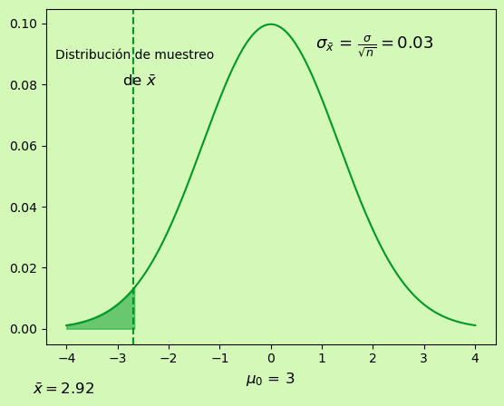

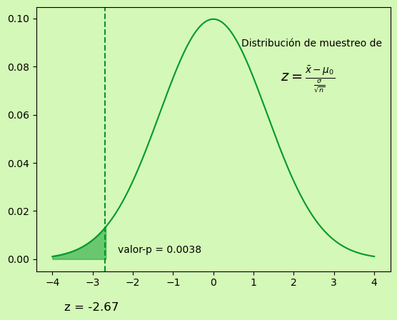

Ahora se puede establecer ya la regla general para determinar cuándo rechazar la hipótesis nula al usar el método del **valor-p**. Dado un nivel de significancia $α$, la regla para el rechazo utilizando el método del **valor-p** es la siguiente.

REGLA PARA EL RECHAZO USANDO EL VALOR-p

Rechazar $H_0$ si el $valor-p ≤ α$

En la prueba para "Café Sierra", el **valor-p** de 0.0038 condujo al rechazo de la hipótesis nula. Aunque la decisión de rechazar se basó en comparar el valor-p con el nivel de significancia especificado por el director de la IBRC, el valor-p observado de 0.0038 sugiere que $H_0$ habría sido rechazada para cualquier valor de $α ≥ 0.0038$. Por esta razón, el valor-p también se conoce como nivel de significancia observado.

### Método del valor crítico

> **El valor crítico** es el valor del estadístico de prueba que corresponde a un área de α (nivel de significancia) en la cola inferior de la distribución de muestreo del estadístico.

En el ejemplo de "Café Sierra", se ilustra el funcionamiento del método del valor crítico. En situaciones donde se conoce la desviación estándar $σ$, la distribución de muestreo del estadístico de prueba $z$ es la distribución normal estándar. El valor crítico es aquel que corresponde a un área de $α = 0.01$ en la cola inferior de esta distribución.

Consultando la tabla de probabilidad normal estándar, se observa que $z ≤ −2.33$ proporciona un área de 0.01 en la cola inferior (ver figura 9.3). Por lo tanto, si el valor del estadístico de prueba obtenido con la muestra es menor o igual a −2.33, el valor-p correspondiente será menor o igual a 0.01, lo que lleva al rechazo de la hipótesis nula. Entonces, en el estudio de "Café Sierra" la regla para el rechazo usando el valor crítico para un nivel de significancia de 0.01 es:

Rechazar $H_0$ si el $z ≤ -2.33$

En nuestro ejemplo, $\bar{x} = 2.92$ y el estadístico de prueba es $z = -2.67$. Como $z = -2.67 < -2.33$, $H_0$ puede ser rechazada y concluir que "Café Sierra" está llenando las latas de manera deficiente.

FIGURA 9.3

Valor crítico = -2.33 en la prueba de hipótesis de "Café Sierra"

## Video:Prueba de hipotesis Valor-P

```python
# importar la clase que permite ver videos
from IPython.display import YouTubeVideo
# crear una instancia del objeto YouTubeVideo
youtube_video=YouTubeVideo('aaJndWRoWWo')
#mostrar el video de youtube
display(youtube_video)
```

# importar la clase que permite ver videos from IPython.display import YouTubeVideo # crear una instancia del objeto YouTubeVideo youtube_video=YouTubeVideo('aaJndWRoWWo') #mostrar el video de youtube display(youtube_video)

[video not shown]

## Video:Prueba de hipotesis Valor Critico

```python
# importar la clase que permite ver videos
from IPython.display import YouTubeVideo
# crear una instancia del objeto YouTubeVideo
youtube_video=YouTubeVideo('FJHh-l7OMT0')
#mostrar el video de youtube
display(youtube_video)
```

# importar la clase que permite ver videos from IPython.display import YouTubeVideo # crear una instancia del objeto YouTubeVideo youtube_video=YouTubeVideo('FJHh-l7OMT0') #mostrar el video de youtube display(youtube_video)

[video not shown]

```python
import numpy as np
import matplotlib.pyplot as plt
from scipy.stats import norm

# Generar datos de la distribución muestral
x = np.linspace(0 - 4 * 1, 0 + 4 * 1, 1000)
y = norm.pdf(x*3, 0, 4)

# Crear la gráfica
fig, ax = plt.subplots()
ax.plot(x, y, color='#009929')
# Establecer el color de fondo
ax.set_facecolor('#d4f8b7')
# Pintar el fondo externo del gráfico
fig.patch.set_facecolor('#D4F8B7')

# Agregar información sobre el error estándar
ax.text(0.02, 0.85, r'Distribución de muestreo de',transform=ax.transAxes, fontsize=9, color='#000')
ax.text(0.13, 0.72, r'$z = \frac{{\bar{x} - \mu_0}}{{\frac{\sigma}{\sqrt{n}}}}$',transform=ax.transAxes, fontsize=15, color='#000')

ax.text(0.02, 0.15, r'α = 0.01',transform=ax.transAxes, fontsize=13, color='#000')

ax.text(0.15, -0.15, r'z = -2.33',transform=ax.transAxes, fontsize=10, color='#000')

# Sombrear la parte de -2.33 hacia la izquierda
ax.fill_between(x, y, where=(x <= -2.33), color='#009929', alpha=0.5)

ax.grid(False)
plt.show()
```

import numpy as np import matplotlib.pyplot as plt from scipy.stats import norm # Generar datos de la distribución muestral x = np.linspace(0 - 4 * 1, 0 + 4 * 1, 1000) y = norm.pdf(x*3, 0, 4) # Crear la gráfica fig, ax = plt.subplots() ax.plot(x, y, color='#009929') # Establecer el color de fondo ax.set_facecolor('#d4f8b7') # Pintar el fondo externo del gráfico fig.patch.set_facecolor('#D4F8B7') # Agregar información sobre el error estándar ax.text(0.02, 0.85, r'Distribución de muestreo de',transform=ax.transAxes, fontsize=9, color='#000') ax.text(0.13, 0.72, r'$z = \frac{{\bar{x} - \mu_0}}{{\frac{\sigma}{\sqrt{n}}}}$',transform=ax.transAxes, fontsize=15, color='#000') ax.text(0.02, 0.15, r'α = 0.01',transform=ax.transAxes, fontsize=13, color='#000') ax.text(0.15, -0.15, r'z = -2.33',transform=ax.transAxes, fontsize=10, color='#000') # Sombrear la parte de -2.33 hacia la izquierda ax.fill_between(x, y, where=(x <= -2.33), color='#009929', alpha=0.5) ax.grid(False) plt.show()

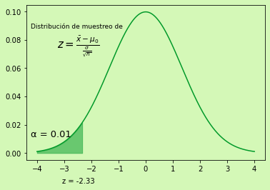

La regla de rechazo se puede generalizar empleando el método del valor crítico para cualquier nivel de significancia. La regla de rechazo en una prueba de cola inferior es la siguiente:

donde $-z_α$ es el valor crítico; es decir, el valor $z$ que proporciona un área de α en la cola inferior de la distribución normal estándar.

El estudio de "Café Sierra" sirvió para ilustrar cómo realizar una prueba de cola inferior. El mismo método general se usa para realizar una prueba de cola superior.

Utilizando el método del valor crítico, la hipótesis nula es rechazada si el valor del estadístico de prueba es mayor o igual al valor crítico $z_α$; en otras palabras, $H_0$ es rechazada si $z ≥ z_α$.

**Para abardor mejor el punto de "PRUEBA DE UNA COLA" se puede observar el siguiente video, para un mejor entendimiento.**

```python
# importar la clase que permite ver videos
from IPython.display import YouTubeVideo
# crear una instancia del objeto YouTubeVideo
youtube_video=YouTubeVideo('UNnQewoA8C0')
#mostrar el video de youtube
display(youtube_video)
```

# importar la clase que permite ver videos from IPython.display import YouTubeVideo # crear una instancia del objeto YouTubeVideo youtube_video=YouTubeVideo('UNnQewoA8C0') #mostrar el video de youtube display(youtube_video)

[video not shown]

# Prueba de dos colas

En las pruebas de hipótesis, la forma general de una **prueba de dos colas** es la siguiente:

| $$H_0: μ = μ_0$$ | $$H_a: μ \neq μ_0$$ |
| --- | --- |

Consideremos el caso de una prueba de hipótesis en la empresa "BoliviaGolfCrafters".

La Federación Boliviana de Golf (FBG) establece estándares para los fabricantes de equipos de golf, y "BoliviaGolfCrafters", una empresa de fabricación de pelotas de golf, utiliza procesos de alta tecnología. La distancia media de recorrido objetivo es 295 yardas, pero el proceso puede desajustarse, produciendo pelotas con distancias diferentes. "BoliviaGolfCrafters" implementa un programa de control de calidad que implica pruebas de hipótesis con muestras de 50 pelotas. La hipótesis nula asume que el proceso está funcionando correctamente, con una distancia media de 295 yardas, mientras que la hipótesis alternativa sugiere que la distancia media no es igual a 295 yardas. Estas hipótesis se expresan como:

$H_0: μ = 295$

$H_a: μ \ne 295$

Este enfoque permite a "BoliviaGolfCrafters" monitorear y ajustar su proceso de fabricación para cumplir con los estándares de la FBG y satisfacer las expectativas de los clientes.

Si la media muestral $\bar{x}$ es significativamente menor o significativamente mayor que 295 yardas, $H_0$ será rechazada. En este caso, se tomarán medidas para ajustar el proceso de manufactura. Por otro lado, si $x$ no se desvía una cantidad significativa de la media hipotética $μ_0 = 295$, $H_0$ no será rechazada, y no se tomará medida alguna para ajustar el proceso de manufactura.

El equipo de control de calidad elige $α = 0.05$ como nivel de significancia para esta prueba. Datos de pruebas anteriores realizadas sabiendo que el proceso está ajustado, indican que se puede suponer que la desviación estándar poblacional se conoce y que su valor es $σ = 12$. Por ende, con un tamaño de muestra $n = 50$, el error estándar $\bar{x}$ es:

### $σ_\bar{x} = \frac{\sigma}{\sqrt{n}} = \frac{12}{\sqrt{50}} = 1.7 $

Como el tamaño de la muestra es grande, el teorema del límite central (capítulo 7) permite concluir que la distribución de muestreo de $\bar{x}$ puede aproximarse mediante una distribución normal. En la (figura 9.4) se ilustra la distribución de muestreo de $\bar{x}$ para la prueba de hipótesis de "BoliviaGolfCrafters" con una media poblacional hipotética de $μ_0 = 295$.

FIGURA 9.4

Distribución de muestreo de $\bar{x}$ en la prueba de hipótesis de "BoliviaGolfCrafters"

```python
import numpy as np
import matplotlib.pyplot as plt
from scipy.stats import norm

# Parámetros de la distribución muestral
media_poblacional = 295
error_estandar = 1.7
# Generar datos de la distribución muestral
x = np.linspace(media_poblacional - 4 * error_estandar, media_poblacional + 4 * error_estandar, 1000)
y = norm.pdf(x, media_poblacional, error_estandar)

# Crear la gráfica
fig, ax = plt.subplots()
ax.plot(x, y, color='#009929')
# Establecer el color de fondo
ax.set_facecolor('#d4f8b7')
# Pintar el fondo externo del gráfico
fig.patch.set_facecolor('#D4F8B7')
ax.set_xlabel(f'$μ_0$ = {media_poblacional}', fontsize=12)

# Agregar información sobre el error estándar
info_error_estandar = r'$σ_\bar{x}$ = $\frac{\sigma}{\sqrt{n}} = \frac{12}{\sqrt{50}} = 1.7$'
ax.text(0.63, 0.85, info_error_estandar, transform=ax.transAxes, fontsize=12, color='#000')
ax.text(0.02, 0.85, r'Distribución de muestreo',transform=ax.transAxes, fontsize=11, color='#000')
ax.text(0.17, 0.77, r'de $\bar{x}$',transform=ax.transAxes, fontsize=12, color='#000')
ax.text(0.50, 0.01, r'|',transform=ax.transAxes, fontsize=12, color='#000')

ax.grid(False)
plt.show()
```

import numpy as np import matplotlib.pyplot as plt from scipy.stats import norm # Parámetros de la distribución muestral media_poblacional = 295 error_estandar = 1.7 # Generar datos de la distribución muestral x = np.linspace(media_poblacional - 4 * error_estandar, media_poblacional + 4 * error_estandar, 1000) y = norm.pdf(x, media_poblacional, error_estandar) # Crear la gráfica fig, ax = plt.subplots() ax.plot(x, y, color='#009929') # Establecer el color de fondo ax.set_facecolor('#d4f8b7') # Pintar el fondo externo del gráfico fig.patch.set_facecolor('#D4F8B7') ax.set_xlabel(f'$μ_0$ = {media_poblacional}', fontsize=12) # Agregar información sobre el error estándar info_error_estandar = r'$σ_\bar{x}$ = $\frac{\sigma}{\sqrt{n}} = \frac{12}{\sqrt{50}} = 1.7$' ax.text(0.63, 0.85, info_error_estandar, transform=ax.transAxes, fontsize=12, color='#000') ax.text(0.02, 0.85, r'Distribución de muestreo',transform=ax.transAxes, fontsize=11, color='#000') ax.text(0.17, 0.77, r'de $\bar{x}$',transform=ax.transAxes, fontsize=12, color='#000') ax.text(0.50, 0.01, r'|',transform=ax.transAxes, fontsize=12, color='#000') ax.grid(False) plt.show()

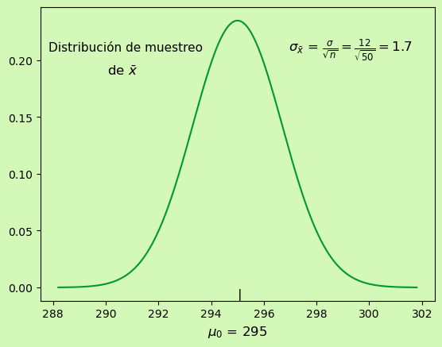

### Método del valor-p

A continuación veremos cómo se calcula el **valor-p** en la prueba de hipótesis de "BoliviaGolfCrafters". Primero calculamos el valor del estadístico de prueba. En el caso en que se conoce $σ$, el estadístico de prueba $z$ es la variable aleatoria normal estándar. Empleando la ecuación ya conocida con $\bar{x} = 297.6$, el valor del estadístico de prueba es:

$$z = \frac{{\bar{x} - \mu_0}}{{\frac{\sigma}{\sqrt{n}}}} = \frac{{297.6 - 295}}{{\frac{12}{\sqrt{50}}}} = 1.53$$

En el cálculo del valor-p para la prueba de hipótesis de dos colas en "BoliviaGolfCrafters", se busca la probabilidad de obtener un valor tan improbable como $z = 1.53$. Dado que es una prueba de dos colas, se consideran tanto los valores $z ≥ 1.53$ como $z ≤ −1.53$. La probabilidad se calcula duplicando el área bajo la curva normal estándar a la derecha de $z = 1.53$. Para $z = 1.53$, el área a la izquierda es $0.9370$, y el área a la derecha es $1.0000 - 0.9370 = 0.0630$. Al duplicar este valor, se obtiene $2(0.0630) = 0.1260$ como el **valor-p**.

FIGURA 9.5

Valor-p en la prueba de hipótesis de "BoliviaGolfCrafters"

```python
import numpy as np
import matplotlib.pyplot as plt
from scipy.stats import norm

# Generar datos de la distribución muestral
x = np.linspace(0 - 1 * 2, 0 + 1 * 2, 1000)
y = norm.pdf(x*3, 0, 2)


# Crear la gráfica
fig, ax = plt.subplots()
ax.plot(x, y, color='#009929')
# Establecer el color de fondo
ax.set_facecolor('#d4f8b7')
# Pintar el fondo externo del gráfico
fig.patch.set_facecolor('#D4F8B7')
ax.set_xlabel(f'$valor-p = 2(0.0630) = 0.1260$', fontsize=10)

# Agregar información sobre el error estándar
ax.text(0.02, 0.15, r'P(z ≤ -1.53) = 0.0630',transform=ax.transAxes, fontsize=9, color='#000')
ax.text(0.76, 0.15, r'P(z ≥ 1.53) = 0.0630',transform=ax.transAxes, fontsize=9, color='#000')

ax.text(0.06, -0.15, r'-1.53',transform=ax.transAxes, fontsize=12, color='#000')
ax.text(0.86, -0.15, r'1.53',transform=ax.transAxes, fontsize=12, color='#000')

# Sombrear la parte de -1.53 hacia la izquierda
ax.fill_between(x, y, where=(x <= -1.53), color='#009929', alpha=0.5)
# Sombrear la parte de 1.53 hacia la derecha
ax.fill_between(x, y, where=(x >= 1.53), color='#009929', alpha=0.5)

ax.grid(False)
plt.show()
```

import numpy as np import matplotlib.pyplot as plt from scipy.stats import norm # Generar datos de la distribución muestral x = np.linspace(0 - 1 * 2, 0 + 1 * 2, 1000) y = norm.pdf(x*3, 0, 2) # Crear la gráfica fig, ax = plt.subplots() ax.plot(x, y, color='#009929') # Establecer el color de fondo ax.set_facecolor('#d4f8b7') # Pintar el fondo externo del gráfico fig.patch.set_facecolor('#D4F8B7') ax.set_xlabel(f'$valor-p = 2(0.0630) = 0.1260$', fontsize=10) # Agregar información sobre el error estándar ax.text(0.02, 0.15, r'P(z ≤ -1.53) = 0.0630',transform=ax.transAxes, fontsize=9, color='#000') ax.text(0.76, 0.15, r'P(z ≥ 1.53) = 0.0630',transform=ax.transAxes, fontsize=9, color='#000') ax.text(0.06, -0.15, r'-1.53',transform=ax.transAxes, fontsize=12, color='#000') ax.text(0.86, -0.15, r'1.53',transform=ax.transAxes, fontsize=12, color='#000') # Sombrear la parte de -1.53 hacia la izquierda ax.fill_between(x, y, where=(x <= -1.53), color='#009929', alpha=0.5) # Sombrear la parte de 1.53 hacia la derecha ax.fill_between(x, y, where=(x >= 1.53), color='#009929', alpha=0.5) ax.grid(False) plt.show()

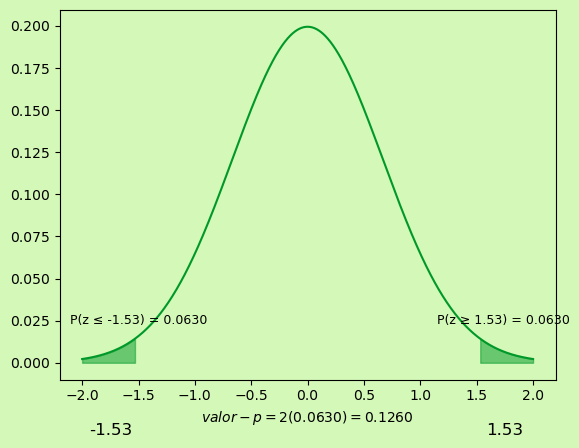

Al comparar el valor-p con el nivel de significancia $α = 0.05$, se encuentra que $0.1260 > 0.05$. Por lo tanto, la hipótesis nula no es rechazada, indicando que no se necesitan medidas para ajustar el proceso de manufactura de "BoliviaGolfCrafters", ya que la distancia media de recorrido no difiere significativamente de $295$ yardas según la muestra analizada.

**CÁLCULO DEL VALOR-p EN UNA PRUEBA DE DOS COLAS**

1. Determine el valor del estadístico de prueba $z$.
2. Si el valor del estadístico de prueba está en la cola superior ($z > 0$), encuentre el área bajo la curva normal estándar a la derecha de $z$; si está en la cola inferior ($z < 0$), localice el área bajo la curva normal estándar a la izquierda de $z$.
3. Duplique el área, o probabilidad, en la cola, obtenida en el paso 2 y determine el valor-p.

### Método del valor crítico

En la figura 9.6 se aprecia que los valores críticos en esta prueba se encuentran tanto en la cola superior como en la cola inferior de la distribución normal estándar. Si el nivel de significancia es $α = 0.05$, en cada cola, el área más allá del valor crítico es $α/2 = 0.05/2 = 0.025$. En la tabla de probabilidad normal estándar se encuentra que los valores críticos para el estadístico de prueba son $-z_0.025 = -1.96$ y $z_0.025 = 1.96. Entonces, al utilizar el método del valor crítico, la regla de rechazo para dos colas es:

Rechazar $H_0$ si el $z ≤ -1.96$ o $z ≥ 1.96$

FIGURA 9.6

Valores críticos en la prueba de hipótesis de "BoliviaGolfCrafters"

```python
import numpy as np
import matplotlib.pyplot as plt
from scipy.stats import norm

# Generar datos de la distribución muestral
x = np.linspace(0 - 3 * 1, 0 + 3 * 1, 1000)
y = norm.pdf(x*3, 0, 3)

# Crear la gráfica
fig, ax = plt.subplots()
ax.plot(x, y, color='#009929')
# Establecer el color de fondo
ax.set_facecolor('#d4f8b7')
# Pintar el fondo externo del gráfico
fig.patch.set_facecolor('#D4F8B7')
ax.set_xlabel(f'<-----|                              Rechazar $H_0$                                |----->', fontsize=10)

# Agregar información sobre el error estándar
ax.text(0.02, 0.20, r'Área = 0.025',transform=ax.transAxes, fontsize=10, color='#000')
ax.text(0.80, 0.20, r'Área = 0.025',transform=ax.transAxes, fontsize=10, color='#000')

ax.text(0.15, -0.15, r'-1.96',transform=ax.transAxes, fontsize=12, color='#000')
ax.text(0.76, -0.15, r'1.96',transform=ax.transAxes, fontsize=12, color='#000')

# Sombrear la parte de -1.96 hacia la izquierda
ax.fill_between(x, y, where=(x <= -1.96), color='#009929', alpha=0.5)
# Sombrear la parte de 1.96 hacia la derecha
ax.fill_between(x, y, where=(x >= 1.96), color='#009929', alpha=0.5)

ax.grid(False)
plt.show()
```

import numpy as np import matplotlib.pyplot as plt from scipy.stats import norm # Generar datos de la distribución muestral x = np.linspace(0 - 3 * 1, 0 + 3 * 1, 1000) y = norm.pdf(x*3, 0, 3) # Crear la gráfica fig, ax = plt.subplots() ax.plot(x, y, color='#009929') # Establecer el color de fondo ax.set_facecolor('#d4f8b7') # Pintar el fondo externo del gráfico fig.patch.set_facecolor('#D4F8B7') ax.set_xlabel(f'<-----| Rechazar $H_0$ |----->', fontsize=10) # Agregar información sobre el error estándar ax.text(0.02, 0.20, r'Área = 0.025',transform=ax.transAxes, fontsize=10, color='#000') ax.text(0.80, 0.20, r'Área = 0.025',transform=ax.transAxes, fontsize=10, color='#000') ax.text(0.15, -0.15, r'-1.96',transform=ax.transAxes, fontsize=12, color='#000') ax.text(0.76, -0.15, r'1.96',transform=ax.transAxes, fontsize=12, color='#000') # Sombrear la parte de -1.96 hacia la izquierda ax.fill_between(x, y, where=(x <= -1.96), color='#009929', alpha=0.5) # Sombrear la parte de 1.96 hacia la derecha ax.fill_between(x, y, where=(x >= 1.96), color='#009929', alpha=0.5) ax.grid(False) plt.show()

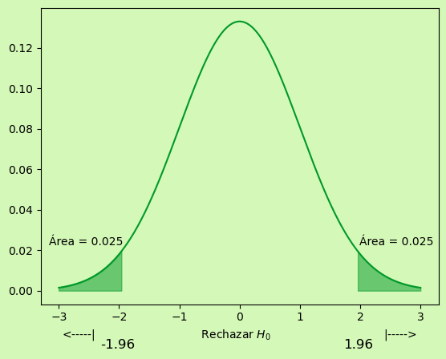

**Para abardor mejor el punto de "PRUEBA DE DOS COLAS" se puede observar el siguiente video, para un mejor entendimiento.**

## Video: Prueba de hipótesis de 2 colas para la media (P-Valor)

```python
# importar la clase que permite ver videos
from IPython.display import YouTubeVideo
# crear una instancia del objeto YouTubeVideo
youtube_video=YouTubeVideo('qusDCMZiUms')
#mostrar el video de youtube
display(youtube_video)
```

# importar la clase que permite ver videos from IPython.display import YouTubeVideo # crear una instancia del objeto YouTubeVideo youtube_video=YouTubeVideo('qusDCMZiUms') #mostrar el video de youtube display(youtube_video)

[video not shown]